# Problem Set_04

Peter Truong (36645133)

version March 24, 2018

### Problem set_04 “Fine-scale phylogenetic architecture”

#### Learning objectives:

- Gain experience estimating diversity within a hypothetical microbial community

#### Part 1: Description and enumeration

Obtain a collection of “microbial” cells from “seawater”. The cells were concentrated from different depth intervals by a marine microbiologist travelling along the Line-P transect in the northeast subarctic Pacific Ocean off the coast of Vancouver Island British Columbia.

Sort out and identify different microbial “species” based on shared properties or traits. Record your data in this Rmarkdown using the example data as a guide.

Once you have defined your binning criteria, separate the cells using the sampling bags provided. These operational taxonomic units (OTUs) will be considered separate “species”. This problem set is based on content available at [What is Biodiversity](http://cnx.org/content/m12179/latest/).

For example, load in the packages you will use.

```r
#To make tables
library(kableExtra)
library(knitr)
#To manipulate and plot data
library(tidyverse)
```

For your sample:

- Construct a table listing each species, its distinguishing characteristics, the name you have given it, and the number of occurrences of the species in the collection.
- Ask yourself if your collection of microbial cells from seawater represents the actual diversity of microorganisms inhabiting waters along the Line-P transect. Were the majority of different species sampled or were many missed?

```r
example_data1 = data.frame(
  number = c(1,2,3,4,5,6,7,8,9,10,11,12,13,14,15,16,17,18,19,20,21,22,23,24,25,26,27,28,29,30,31,32),
  name = c("M&M green", "m&m red", "m&m blue", "m&m yellow", "m&m brown", "m&m orange", "skittle brown", "skittle red", "skittle green", "skittle orange", "skittle yellow", "gummy bear red", "gummy bear pink", "gummy bear green", "gummy bear orange", "gummy bear yellow", "gummy bear white", "M&I pink", "M&I green", "M&I yellow", "M&I orange", "M&I red", "gummy worm red", "balls yellow", "balls green", "balls purple", "balls orange", "balls red", "chocolate kiss", "lego pink", "lego yellow", "lego blue"),
  characteristics = c("green coloured spherical chocolates", "red coloured spherical chocolates", "blue coloured spherical chocolates", "yellow coloured spherical chocolates", "brown coloured spherical chocolates", "orange coloured spherical chocolates", "brown coloured spherical chewies", "red coloured spherical chewies", "green coloured spherical chewies", "orange coloured spherical chewies", "yellow coloured spherical chewies", "red Gummy bears", "pink Gummy bears", "green Gummy bears", "orange Gummy bears", "yellow Gummy bears", "white Gummy bears", "pink coloured oval chewies", "green coloured oval chewies", "yellow coloured oval chewies", "orange coloured oval chewies", "red coloured oval chewies", "red gummy worms", "yellow spherical chewies", "green spherical chewies", "purple spherical chewies", "orange spherical chewies", "red spherical chewies", "pyrimidal chocolates", "pink coloured lego-like candy", "yellow coloured lego-like candy", "blue coloured lego-like candy"),
  occurences = c(7, 10, 11, 6, 6, 16, 4, 8, 6, 3, 8, 4, 3, 3, 2, 1, 3, 4, 2, 3, 3, 7, 2, 1, 0, 0, 1, 2, 3, 2, 2, 2)
)
```

```r
example_data1 %>%
  kable("html") %>%
  kable_styling(bootstrap_options = "striped", font_size = 10, full_width = F)
```

| number | name | characteristics | occurences |
| --- | --- | --- | --- |
| 1 | M&M green | green coloured spherical chocolates | 7 |
| 2 | m&m red | red coloured spherical chocolates | 10 |
| 3 | m&m blue | blue coloured spherical chocolates | 11 |
| 4 | m&m yellow | yellow coloured spherical chocolates | 6 |
| 5 | m&m brown | brown coloured spherical chocolates | 6 |
| 6 | m&m orange | orange coloured spherical chocolates | 16 |
| 7 | skittle brown | brown coloured spherical chewies | 4 |
| 8 | skittle red | red coloured spherical chewies | 8 |
| 9 | skittle green | green coloured spherical chewies | 6 |
| 10 | skittle orange | orange coloured spherical chewies | 3 |
| 11 | skittle yellow | yellow coloured spherical chewies | 8 |
| 12 | gummy bear red | red Gummy bears | 4 |
| 13 | gummy bear pink | pink Gummy bears | 3 |
| 14 | gummy bear green | green Gummy bears | 3 |
| 15 | gummy bear orange | orange Gummy bears | 2 |
| 16 | gummy bear yellow | yellow Gummy bears | 1 |
| 17 | gummy bear white | white Gummy bears | 3 |
| 18 | M&I pink | pink coloured oval chewies | 4 |
| 19 | M&I green | green coloured oval chewies | 2 |
| 20 | M&I yellow | yellow coloured oval chewies | 3 |
| 21 | M&I orange | orange coloured oval chewies | 3 |
| 22 | M&I red | red coloured oval chewies | 7 |
| 23 | gummy worm red | red gummy worms | 2 |
| 24 | balls yellow | yellow spherical chewies | 1 |
| 25 | balls green | green spherical chewies | 0 |
| 26 | balls purple | purple spherical chewies | 0 |
| 27 | balls orange | orange spherical chewies | 1 |
| 28 | balls red | red spherical chewies | 2 |
| 29 | chocolate kiss | pyrimidal chocolates | 3 |
| 30 | lego pink | pink coloured lego-like candy | 2 |
| 31 | lego yellow | yellow coloured lego-like candy | 2 |
| 32 | lego blue | blue coloured lego-like candy | 2 |

#### Part 2: Collector’s curve

To help answer the questions raised in Part 1, you will conduct a simple but informative analysis that is a standard practice in biodiversity surveys. This analysis involves constructing a collector’s curve that plots the cumulative number of species observed along the y-axis and the cumulative number of individuals classified along the x-axis. This curve is an increasing function with a slope that will decrease as more individuals are classified and as fewer species remain to be identified. If sampling stops while the curve is still rapidly increasing then this indicates that sampling is incomplete and many species remain undetected. Alternatively, if the slope of the curve reaches zero (flattens out), sampling is likely more than adequate.

To construct the curve for your samples, choose a cell within the collection at random. This will be your first data point, such that X = 1 and Y = 1. Next, move consistently in any direction to a new cell and record whether it is different from the first. In this step X = 2, but Y may remain 1 or change to 2 if the individual represents a new species. Repeat this process until you have proceeded through all cells in your collection.

For your sample:

- Create a collector’s curve.
- Does the curve flatten out? If so, after how many individual cells have been collected?

Yes the curve flattens out. It flattens out at cell number 93/135

- What can you conclude from the shape of your collector’s curve as to your depth of sampling?

From my collector’s curve, it indicates that the majority of the species were detected and that only few species remained undetected. As a result, the sample was sufficient to reveal that the majority of speices had been sampled from the original community pool.

```r
example_data2 = data.frame(
  x = c(1,2,3,4,5,6,7,8,9,10,11,12,13,14,15,16,17,18,19,20,21,22,23,24,25,26,27,28,29,30,31,31,33,34,35,36,37,38,39,40,41,42,43,44,45,46,47,48,49,50,51,52,53,54,55,56,57,58,59,60,61,62,63,64,65,66,67,68,69,70,71,72,73,74,75,76,77,78,79,80,81,82,83,84,85,86,87,88,89,90,91,92,93,94,95,96,97,98,99,100,101,102,103,104,105,106,107,108,109,110,111,112,113,114,115,116,117,118,119,120,121,122,123,124,125,126,127,128,129,130,131,132,133,134,135),
  y = c(1,2,3,3,4,5,5,6,6,7,7,8,8,8,9,10,10,11,11,11,12,13,13,14,15,16,17,18,18,19,19,20,20,20,20,20,21,21,21,21,22,22,22,23,23,23,24,25,25,25,26,26,27,27,27,27,28,28,28,28,28,28,28,28,29,29,30,30,31,31,31,31,31,31,31,31,31,31,31,31,31,31,31,31,31,31,31,31,31,31,31,31,31,32,32,32,32,32,32,32,32,32,32,32,32,32,32,32,32,32,32,32,32,32,32,32,32,32,32,32,32,32,32,32,32,32,32,32,32,32,32,32,32,32,32)
)
```

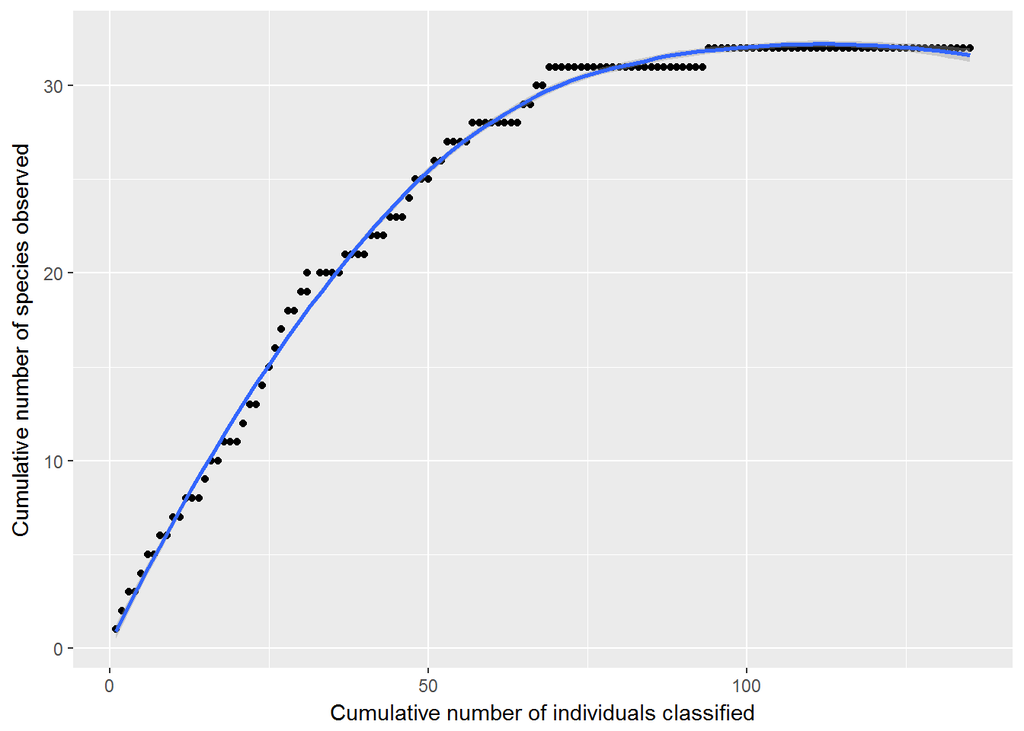

```r
ggplot(example_data2, aes(x=x, y=y))+
  geom_point() +
  geom_smooth() +
  labs(x="Cumulative number of individuals classified", y="Cumulative number of species observed")
```

#### Part 3: Diversity estimates (alpha diversity)

Using the table from Part 1, calculate species diversity using the following indices or metrics.

##### Diversity: Simpson Reciprocal Index

$\frac{1}{D}$ where $D = \sum p_i^2$

$p_i$ = the fractional abundance of the $i^{th}$ species

For example, using the example data 1 with 3 species with 2, 4, and 1 individuals each, D =

```r
species1 = 2/(2+4+1)
species2 = 4/(2+4+1)
species3 = 1/(2+4+1)

1 / (species1^2 + species2^2 + species3^2)
```

```
## [1] 2.333333
```

The higher the value is, the greater the diversity. The maximum value is the number of species in the sample, which occurs when all species contain an equal number of individuals. Because the index reflects the number of species present (richness) and the relative proportions of each species with a community (evenness), this metric is a diveristy metric. Consider that a community can have the same number of species (equal richness) but manifest a skewed distribution in the proportion of each species (unequal evenness), which would result in different diveristy values.

- What is the Simpson Reciprocal Index for your sample?

The simpson reciprocal index for my sample is 19.12382.

```r
species1 = 7/(135)
species2 = 10/(135)
species3 = 11/(135)
species4 = 6/(135)
species5 = 6/(135)
species6 = 16/(135)
species7 = 4/(135)
species8 = 8/(135)
species9 = 6/(135)
species10 = 3/(135)
species11 = 8/(135)
species12 = 4/(135)
species13 = 3/(135)
species14 = 3/(135)
species15 = 2/(135)
species16 = 1/(135)
species17 = 3/(135)
species18 = 4/(135)
species19 = 2/(135)
species20 = 3/(135)
species21 = 3/(135)
species22 = 7/(135)
species23 = 2/(135)
species24 = 1/(135)
species25 = 0/(135)
species26 = 0/(135)
species27 = 1/(135)
species28 = 2/(135)
species29 = 3/(135)
species30 = 2/(135)
species31 = 2/(135)
species32 = 2/(135)


1 / (species1^2 + species2^2 + species3^2 + species4^2 + species5^2 + species6^2 + species7^2 + species8^2 + species9^2 + species10^2 + species11^2 + species12^2 + species13^2 + species14^2 + species15^2 + species16^2 + species17^2 + species18^2 + species19^2 + species20^2 + species21^2 + species22^2 + species23^2 + species24^2 + species25^2 + species26^2 + species27^2 + species28^2 + species29^2 + species30^2 + species31^2 + species32^2)
```

```
## [1] 19.12382
```

##### Richness: Chao1 richness estimator

Another way to calculate diversity is to estimate the number of species that are present in a sample based on the empirical data to give an upper boundary of the richness of a sample. Here, we use the Chao1 richness estimator.

$S_{chao1} = S_{obs} + \frac{a^2}{2b})$

$S_{obs}$ = total number of species observed a = species observed once b = species observed twice or more

So for our previous example community of 3 species with 2, 4, and 1 individuals each, $S_{chao1}$ =

```r
3 + 1^2/(2*2)
```

```
## [1] 3.25
```

- What is the chao1 estimate for your sample?

```r
30 + 3^2/(27*2)
```

```
## [1] 30.16667
```

The chao1 estimate for my sample is 30.17

#### Part 4: Alpha-diversity functions in R

We’ve been doing the above calculations by hand, which is a very good exercise to aid in understanding the math behind these estimates. Not surprisingly, these same calculations can be done with R functions. Since we just have a species table, we will use the `vegan` package. You will need to install this package if you have not done so previously.

```r
library(vegan)
```

First, we must remove the unnecesary data columns and transpose the data so that `vegan` reads it as a species table with species as columns and rows as samples (of which you only have 1).

```r
example_data1_diversity =
  example_data1 %>%
  select(name, occurences) %>%
  spread(name, occurences)

example_data1_diversity
```

```
##   balls green balls orange balls purple balls red balls yellow
## 1           0            1            0         2            1
##   chocolate kiss gummy bear green gummy bear orange gummy bear pink
## 1              3                3                 2               3
##   gummy bear red gummy bear white gummy bear yellow gummy worm red
## 1              4                3                 1              2
##   lego blue lego pink lego yellow M&I green M&I orange M&I pink M&I red
## 1         2         2           2         2          3        4       7
##   M&I yellow m&m blue m&m brown M&M green m&m orange m&m red m&m yellow
## 1          3       11         6         7         16      10          6
##   skittle brown skittle green skittle orange skittle red skittle yellow
## 1             4             6              3           8              8
```

Then we can calculate the Simpson Reciprocal Index using the `diversity` function.

```r
diversity(example_data1_diversity, index="invsimpson")
```

```
## [1] 19.12382
```

And we can calculate the Chao1 richness estimator (and others by default) with the the `specpool` function for extrapolated species richness. This function rounds to the nearest whole number so the value will be slightly different that what you’ve calculated above.

```r
specpool(example_data1_diversity)
```

```
##     Species chao chao.se jack1 jack1.se jack2 boot boot.se n
## All      30   30       0    30        0    30   30       0 1
```

In Project 1, you will also see functions for calculating alpha-diversity in the `phyloseq` package since we will be working with data in that form.

For your sample:

- What is the Simpson Reciprocal Index using the R function?
- What is the chao1 estimate using the R function?
  - Verify that these values match your previous calculations.

#### Part 5: Concluding activity

If you are stuck on some of these final questions, reading the [Kunin et al. 2010](https://www.ncbi.nlm.nih.gov/pubmed/19725865) and [Lundin et al. 2012](https://www.ncbi.nlm.nih.gov/pubmed/23760801) papers may provide helpful insights.

- How does the measure of diversity depend on the definition of species in your samples?
- Can you think of alternative ways to cluster or bin your data that might change the observed number of species?
- How might different sequencing technologies influence observed diversity in a sample?